# Simulation exercise

### 1. Show where the distribution is centered at and compare it to the theoretical center of the distribution

```r
set.seed(200)
lambda <- 2
mexp <- NULL
for (i in 1 : 1000) (mexp = c(mexp, mean(rexp(40,lambda))))
```

The following code computes the theorical center of the distribution.

```r
1/lambda
```

```
## [1] 0.5
```

```r
espsim <- mean(mexp)
espsim
```

```
## [1] 0.4984
```

The distribution center is very close to its theorical value.

### 2. Show how variable it is and compare it to the theoretical variance of the distribution.

The following code computes the theorical variance of the distribution.

```r
varsim <- (1/lambda)^2/40
varsim
```

```
## [1] 0.00625
```

```r
var(mexp)
```

```
## [1] 0.006581
```

The variance of the distribution is very close to its theorical value.

### 3. Show that the distribution is approximately normal.

The Central Limit Theorem states that the distribution of averages of iid variables becomes that of a standard normal as the sample size increases.

So we can say that mexp is approximately a normal density with an expectancy of espsim and a variance of varsim.

The following codes will illustrate this by a plot.

This codes simulate the normal density with an expectancy of epsim and a variance of varsim.

```r
norm <- rnorm(1000, mean = espsim, sd = sqrt(varsim))
```

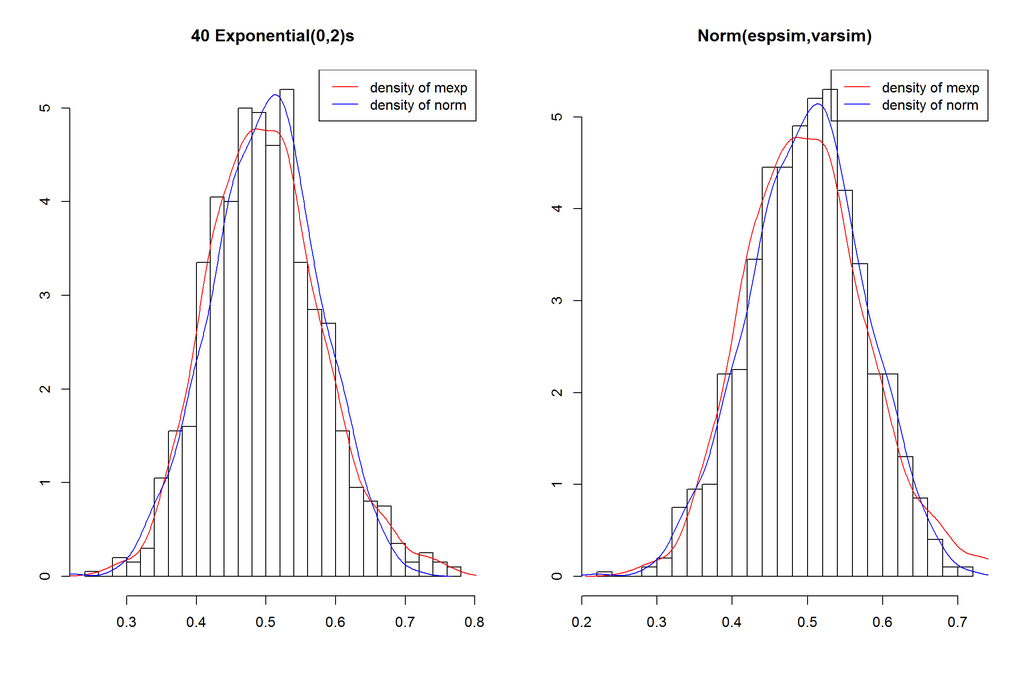

```r
par(mfrow = c(1,2))
hist(mexp, breaks = 24,xlab = "",ylab = "", prob=TRUE,main = "40 Exponential(0,2)s")
lines(density(mexp),col = "red")
lines(density(norm), col = "blue")
legend("topright", legend = c("density of mexp","density of norm"), col = c("red","blue"), lwd = 1)
hist(norm,breaks = 24,xlab = "",ylab = "", prob=TRUE,main = "Norm(espsim,varsim)")
lines(density(mexp),col = "red")
lines(density(norm), col = "blue")
legend("topright", legend = c("density of mexp","density of norm"), col = c("red","blue"), lwd = 1)
```